# Introduction to Python Project : FoodHub Data Analysis

### **Question 13:** The company wants to provide a promotional offer in the advertisement of the restaurants. The condition to get the offer is that the restaurants must have a rating count of more than 50 and the average rating should be greater than 4. Find the restaurants fulfilling the criteria to get the promotional offer. [3 marks]

```python
# Aggregate the resaurants by name and get the count of ratings and average rating
qualified_restaurants = data.groupby('restaurant_name').agg(rating_count=('rating', 'count'),
                                                            avg_rating=('rating', 'mean'))
# Filter the restaurants with more than 50 ratings and an average rating greater than 4
qualified_restaurants = qualified_restaurants[(qualified_restaurants['rating_count'] > 50) & (qualified_restaurants['avg_rating'] > 4)]
```

```python
print("Resaurants eligible for the promotional offers are:\n", "\n".join(qualified_restaurants.index.tolist()))
```

```
Resaurants eligible for the promotional offers are:
 Blue Ribbon Fried Chicken
Blue Ribbon Sushi
Shake Shack
The Meatball Shop
```

#### Observations:

**Restaurants eligible for promotional offers:**

- Blue Ribbon Fried Chicken
- Blue Ribbon Sushi
- Shake Shack
- The Meatball Shop

### **Question 14:** The company charges the restaurant 25% on the orders having cost greater than 20 dollars and 15% on the orders having cost greater than 5 dollars. Find the net revenue generated by the company across all orders. [3 marks]

```python
net_revenue_25 = data[(data['cost_of_the_order'] > 20.)]['cost_of_the_order'].sum() * 0.25
net_revenue_15 = data[(data['cost_of_the_order'] > 5.) & (data['cost_of_the_order'] <= 20.)]['cost_of_the_order'].sum() * 0.15
```

```python
print(f"Net revenue generated by company across all orders:\n{net_revenue_25 + net_revenue_15:.2f}$")
```

```
Net revenue generated by company across all orders:
6166.30$
```

#### Observations:

**Net revenue generated by company across all orders : 6166.30$**

### **Question 15:** The company wants to analyze the total time required to deliver the food. What percentage of orders take more than 60 minutes to get delivered from the time the order is placed? (The food has to be prepared and then delivered.) [2 marks]

```python
total_time = data['food_preparation_time'] + data['delivery_time']
total_time = total_time[total_time > 60]
percent_orders = total_time.shape[0] / data.shape[0] * 100
print(f"Percentage of orders taking more than 60 minutes to deliver the food:\n{percent_orders:.2f}%")
```

```
Percentage of orders taking more than 60 minutes to deliver the food:
10.54%
```

#### Observations:

**Percentage of orders taking more than 60 minutes to deliver the food: 10.54%**

### **Question 16:** The company wants to analyze the delivery time of the orders on weekdays and weekends. How does the mean delivery time vary during weekdays and weekends? [2 marks]

```python
data.groupby('day_of_the_week').agg(avg_delivery_time=('delivery_time', 'mean')).reset_index()
```

|  | day_of_the_week | avg_delivery_time |
| --- | --- | --- |
| 0 | Weekday | 28.340037 |
| 1 | Weekend | 22.470022 |

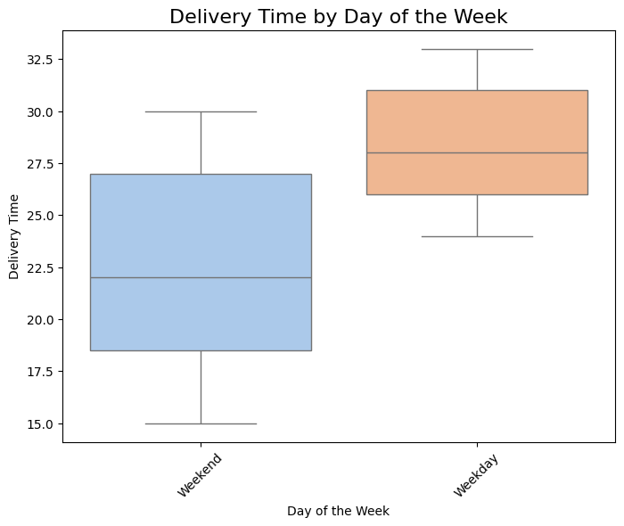

```python
plt.figure(figsize=(8, 6))
sns.boxplot(x='day_of_the_week', y='delivery_time', data=data, palette="pastel")
plt.title("Delivery Time by Day of the Week", fontsize=16)
plt.xticks(rotation=45)
plt.ylabel("Delivery Time")
plt.xlabel("Day of the Week")
plt.show()
```

#### Observations:

- Delivery times on weekdays tend to be higher than delivery times on weekends
- Median delivery times on weekdays are higher than 75 percentile of delivery times over the weekends

### Conclusion and Recommendations

### **Question 17:** What are your conclusions from the analysis? What recommendations would you like to share to help improve the business? (You can use cuisine type and feedback ratings to drive your business recommendations.) [6 marks]

### Conclusions:

**Cuisine Popularity**

```python
cuisine_counts = data['cuisine_type'].value_counts()[:4]
print(cuisine_counts)
```

```
cuisine_type
American    584
Japanese    470
Italian     298
Chinese     215
Name: count, dtype: int64
```

Focus on promoting the top cuisines (e.g., American, Japanese) to attract more customers.

**Order Cost Distribution**

```python
avg_cost_by_cuisine = data.groupby('cuisine_type')['cost_of_the_order'].mean().sort_values(ascending=False)
print(avg_cost_by_cuisine)
```

```
cuisine_type
French            19.793889
Southern          19.300588
Thai              19.207895
Spanish           18.994167
Middle Eastern    18.820612
Mexican           16.933117
Indian            16.919726
Italian           16.418691
American          16.319829
Chinese           16.305209
Japanese          16.304532
Mediterranean     15.474783
Korean            14.001538
Vietnamese        12.882857
Name: cost_of_the_order, dtype: float64
```

- Highlight cuisines with higher average order costs in marketing campaigns.
- As data indicates, French, Southern and Thai have high average order cost.

**Delivery Time**

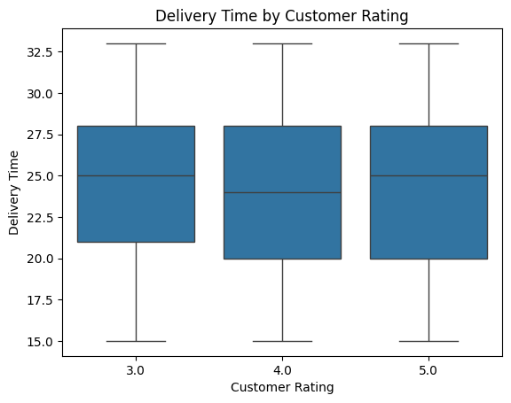

```python
sns.boxplot(x='rating', y='delivery_time', data=data)
plt.title('Delivery Time by Customer Rating')
plt.xlabel('Customer Rating')
plt.ylabel('Delivery Time')
plt.show()
```

- Delivery time doesn't seem to influence customer ratings too much.
- Reduce delivery times to improve customer satisfaction and ratings

**Day of the Week Trends**

```python
orders_by_day = data_copy.groupby('day_of_the_week')['order_id'].count()
avg_cost_by_day = data_copy.groupby('day_of_the_week')['cost_of_the_order'].mean()
print(orders_by_day)
print()
print(avg_cost_by_day)
```

```
day_of_the_week
Weekday     547
Weekend    1351
Name: order_id, dtype: int64

day_of_the_week
Weekday    16.311188
Weekend    16.574833
Name: cost_of_the_order, dtype: float64
```

Offer discounts or promotional offers on weekdays to boost sales.